# Unsupervised Learning

The key distinction between the two is:

- Supervised Learning has BOTH *Input* and *Output* information
- Unsupervised Learning ONLY has *Input* information

Most Unsupervised algorithms come down to some form of Clustering

> **Clustering** is the task of grouping a set of objects in such a way that objects in the same group are more similar to each other than to those in other groups. -Wikipedia

There are SEVERAL different strategies for identifying clusters in a dataset, but the most commonly used is K-Means Clustering.

## K-Means Clustering Algorithm

Before starting, pick $K$. This will be the number of groups identified.

1. Randomly select the $K$ group centers.
2. Find the distance from the group centers to all points in data set.
   - Identify each data point as "belonging" to the group that is the closest
3. Update the group centers to be the average of all the points in the group
4. Repeat step 2 and 3 until the group centers stop changing

[figure not shown]

```python
from IPython.lib.display import YouTubeVideo
YouTubeVideo('nXY6PxAaOk0')
```

[video not shown]

## Doing our own

```python
import pandas as pd
import numpy as np
import matplotlib.pyplot as plt
import seaborn as sns
import plotly.express as px
from sklearn.cluster import KMeans
```

```python
auto = pd.read_csv("https://raw.githubusercontent.com/JWarmenhoven/ISLR-python/master/Notebooks/Data/Auto.csv", na_values="?").dropna()
auto.head()
```

|  | mpg | cylinders | displacement | horsepower | weight | acceleration | year | origin | name |
| --- | --- | --- | --- | --- | --- | --- | --- | --- | --- |
| 0 | 18.0 | 8 | 307.0 | 130.0 | 3504 | 12.0 | 70 | 1 | chevrolet chevelle malibu |
| 1 | 15.0 | 8 | 350.0 | 165.0 | 3693 | 11.5 | 70 | 1 | buick skylark 320 |
| 2 | 18.0 | 8 | 318.0 | 150.0 | 3436 | 11.0 | 70 | 1 | plymouth satellite |
| 3 | 16.0 | 8 | 304.0 | 150.0 | 3433 | 12.0 | 70 | 1 | amc rebel sst |
| 4 | 17.0 | 8 | 302.0 | 140.0 | 3449 | 10.5 | 70 | 1 | ford torino |

```
[]
```

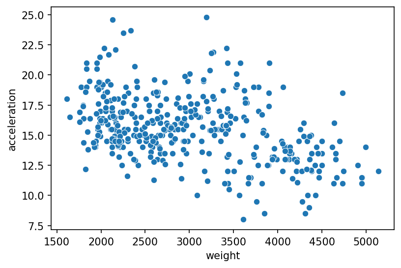

```python
plt.figure(dpi=150)
sns.scatterplot(x="weight", y="acceleration", data=auto)
plt.plot()
```

```python
X = auto[['weight', 'acceleration']]
```

```python
X
```

|  | weight | acceleration |
| --- | --- | --- |
| 0 | 3504 | 12.0 |
| 1 | 3693 | 11.5 |
| 2 | 3436 | 11.0 |
| 3 | 3433 | 12.0 |
| 4 | 3449 | 10.5 |
| ... | ... | ... |
| 392 | 2790 | 15.6 |
| 393 | 2130 | 24.6 |
| 394 | 2295 | 11.6 |
| 395 | 2625 | 18.6 |
| 396 | 2720 | 19.4 |

392 rows × 2 columns

```python
kmeans = KMeans(n_clusters=2).fit(X)
```

```python
kmeans
```

```
KMeans(algorithm='auto', copy_x=True, init='k-means++', max_iter=300,
       n_clusters=2, n_init=10, n_jobs=None, precompute_distances='auto',
       random_state=None, tol=0.0001, verbose=0)
```

```python
kmeans.predict(X)
```

```
array([0, 0, 0, 0, 0, 0, 0, 0, 0, 0, 0, 0, 0, 1, 1, 1, 1, 1, 1, 1, 1, 1,
       1, 1, 1, 0, 0, 0, 0, 1, 1, 1, 1, 0, 0, 0, 0, 0, 0, 0, 0, 0, 0, 0,
       1, 1, 0, 0, 1, 1, 1, 1, 1, 1, 1, 1, 1, 1, 1, 1, 1, 0, 0, 0, 0, 0,
       0, 0, 0, 0, 1, 0, 0, 0, 0, 1, 1, 1, 1, 1, 1, 1, 1, 1, 0, 0, 0, 0,
       0, 0, 0, 0, 0, 0, 0, 0, 1, 0, 1, 1, 1, 1, 0, 0, 0, 0, 1, 1, 1, 1,
       1, 1, 1, 1, 0, 0, 1, 1, 1, 1, 0, 1, 1, 0, 1, 1, 0, 1, 1, 1, 1, 0,
       0, 0, 0, 0, 0, 0, 0, 1, 1, 1, 1, 1, 1, 1, 1, 1, 1, 1, 0, 0, 0, 0,
       0, 0, 0, 0, 0, 0, 0, 0, 1, 0, 0, 1, 1, 1, 1, 1, 1, 1, 1, 1, 0, 1,
       1, 1, 1, 1, 1, 1, 1, 1, 1, 0, 0, 0, 0, 0, 0, 1, 1, 1, 1, 1, 1, 0,
       0, 0, 0, 1, 1, 1, 1, 0, 0, 0, 1, 0, 0, 0, 0, 0, 1, 1, 1, 1, 1, 0,
       0, 0, 0, 0, 0, 0, 0, 0, 0, 0, 0, 1, 1, 1, 1, 1, 1, 1, 1, 1, 1, 1,
       1, 1, 1, 1, 1, 0, 0, 0, 0, 0, 1, 1, 0, 0, 0, 1, 0, 0, 0, 0, 0, 0,
       1, 1, 1, 1, 1, 1, 1, 1, 1, 0, 1, 0, 1, 1, 0, 1, 1, 0, 0, 0, 0, 0,
       0, 0, 0, 0, 0, 1, 1, 1, 1, 0, 0, 0, 0, 1, 1, 1, 1, 1, 1, 1, 1, 1,
       1, 1, 1, 1, 1, 1, 0, 1, 1, 1, 1, 1, 1, 1, 1, 1, 1, 1, 0, 1, 1, 1,
       1, 1, 1, 1, 1, 1, 1, 1, 1, 1, 1, 1, 1, 1, 1, 1, 1, 1, 1, 1, 1, 1,
       1, 1, 0, 0, 1, 1, 0, 0, 1, 0, 1, 1, 1, 1, 1, 1, 1, 1, 1, 1, 1, 1,
       1, 1, 1, 1, 1, 1, 1, 1, 1, 1, 1, 1, 1, 1, 1, 1, 1, 1], dtype=int32)
```

```python
groups = kmeans.predict(X)
```

```python
groups==0
```

```
array([ True,  True,  True,  True,  True,  True,  True,  True,  True,
        True,  True,  True,  True, False, False, False, False, False,
       False, False, False, False, False, False, False,  True,  True,
        True,  True, False, False, False, False,  True,  True,  True,
        True,  True,  True,  True,  True,  True,  True,  True, False,
       False,  True,  True, False, False, False, False, False, False,
       False, False, False, False, False, False, False,  True,  True,
        True,  True,  True,  True,  True,  True,  True, False,  True,
        True,  True,  True, False, False, False, False, False, False,
       False, False, False,  True,  True,  True,  True,  True,  True,
        True,  True,  True,  True,  True,  True, False,  True, False,
       False, False, False,  True,  True,  True,  True, False, False,
       False, False, False, False, False, False,  True,  True, False,
       False, False, False,  True, False, False,  True, False, False,
        True, False, False, False, False,  True,  True,  True,  True,
        True,  True,  True,  True, False, False, False, False, False,
       False, False, False, False, False, False,  True,  True,  True,
        True,  True,  True,  True,  True,  True,  True,  True,  True,
       False,  True,  True, False, False, False, False, False, False,
       False, False, False,  True, False, False, False, False, False,
       False, False, False, False, False,  True,  True,  True,  True,
        True,  True, False, False, False, False, False, False,  True,
        True,  True,  True, False, False, False, False,  True,  True,
        True, False,  True,  True,  True,  True,  True, False, False,
       False, False, False,  True,  True,  True,  True,  True,  True,
        True,  True,  True,  True,  True,  True, False, False, False,
       False, False, False, False, False, False, False, False, False,
       False, False, False, False,  True,  True,  True,  True,  True,
       False, False,  True,  True,  True, False,  True,  True,  True,
        True,  True,  True, False, False, False, False, False, False,
       False, False, False,  True, False,  True, False, False,  True,
       False, False,  True,  True,  True,  True,  True,  True,  True,
        True,  True,  True, False, False, False, False,  True,  True,
        True,  True, False, False, False, False, False, False, False,
       False, False, False, False, False, False, False, False,  True,
       False, False, False, False, False, False, False, False, False,
       False, False,  True, False, False, False, False, False, False,
       False, False, False, False, False, False, False, False, False,
       False, False, False, False, False, False, False, False, False,
       False, False, False,  True,  True, False, False,  True,  True,
       False,  True, False, False, False, False, False, False, False,
       False, False, False, False, False, False, False, False, False,
       False, False, False, False, False, False, False, False, False,
       False, False, False, False, False])
```

```
[]
```

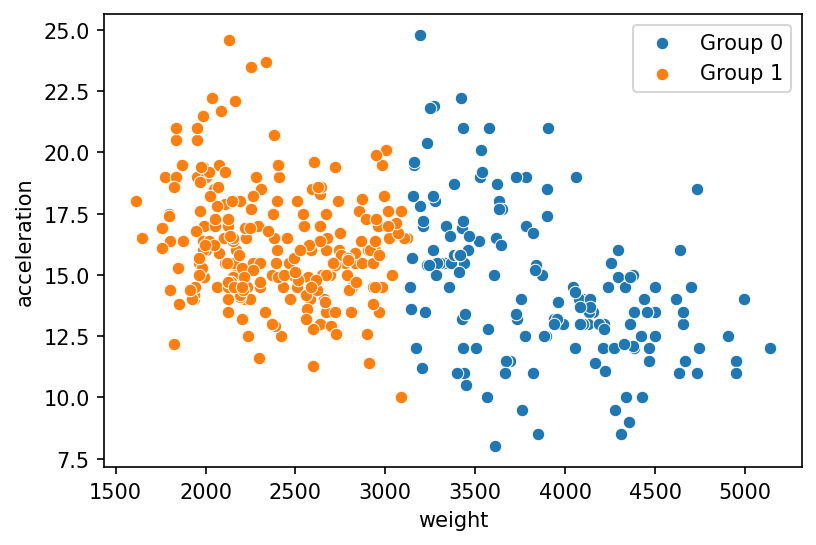

```python
plt.figure(dpi=150)
sns.scatterplot(x="weight", y="acceleration", data=auto.iloc[groups==0])
sns.scatterplot(x="weight", y="acceleration", data=auto.iloc[groups==1])
plt.legend(["Group 0", "Group 1"])
plt.plot()
```

## Each start is random!

So we could end up with different groups!

```
[]
```

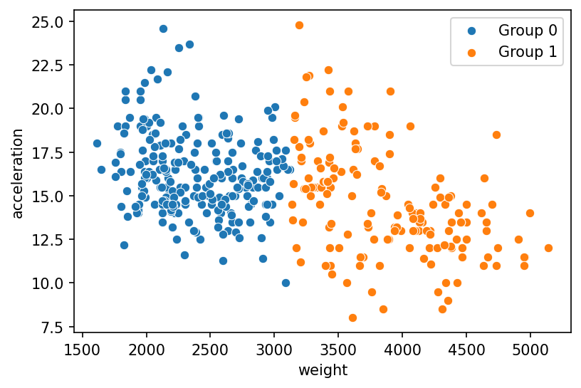

```python
groups = KMeans(n_clusters=2).fit(X).predict(X)
plt.figure(dpi=150)
sns.scatterplot(x="weight", y="acceleration", data=auto.iloc[groups==0])
sns.scatterplot(x="weight", y="acceleration", data=auto.iloc[groups==1])
plt.legend(["Group 0", "Group 1"])
plt.plot()
```

## More than two groups?

While we may not **see** more than two groups, KMeans will happily try to find them.

```
[]
```

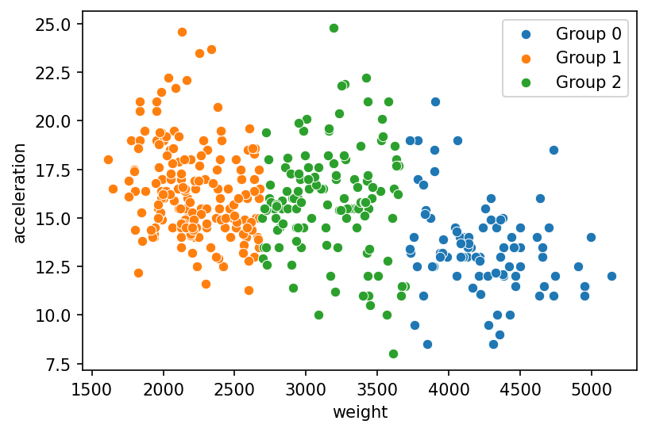

```python
groups = KMeans(n_clusters=3).fit(X).predict(X)
plt.figure(dpi=150)
sns.scatterplot(x="weight", y="acceleration", data=auto.iloc[groups==0])
sns.scatterplot(x="weight", y="acceleration", data=auto.iloc[groups==1])
sns.scatterplot(x="weight", y="acceleration", data=auto.iloc[groups==2])
plt.legend(["Group 0", "Group 1", "Group 2"])
plt.plot()
```

```
[]
```

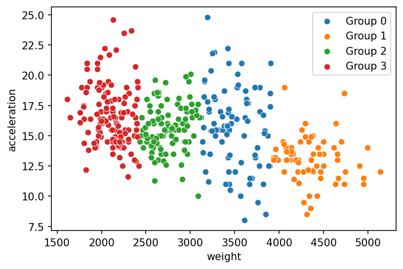

```python
groups = KMeans(n_clusters=4).fit(X).predict(X)
plt.figure(dpi=150)
sns.scatterplot(x="weight", y="acceleration", data=auto.iloc[groups==0])
sns.scatterplot(x="weight", y="acceleration", data=auto.iloc[groups==1])
sns.scatterplot(x="weight", y="acceleration", data=auto.iloc[groups==2])
sns.scatterplot(x="weight", y="acceleration", data=auto.iloc[groups==3])
plt.legend(["Group 0", "Group 1", "Group 2", "Group 3"])
plt.plot()
```

## Hierarchical Clustering

The other dominant strategy for finding groups in a data set.

> **Hierarchical clustering** is a method of cluster analysis which seeks to build a hierarchy of clusters. -Wikipedia

There are two main varieties: *top down* and *bottom up*. They differ in whether you start with individual groups or a single group, then split. Either way, the individual **distance** between data points is used to create the groups.

[figure not shown]

The result of every hierarchical cluster algorithm is a **Dendogram**, a visual image that shows how groups are formed. This picture gives us the *complete grouping* available.

Advantages of hierarchical clustering include:

- The ability to use **ANY** distance metric
- All possible groups are found

Some of the disadvantages include:

- Greater computational cost
- Difficult to know what "level" of clustering is correct
- Sensitive to the distance metric used

```python
from sklearn.cluster import AgglomerativeClustering
from scipy.cluster.hierarchy import dendrogram, linkage
```

```python
h_groups = AgglomerativeClustering().fit(X)
```

```python
h_groups.labels_
```

```
array([1, 1, 1, 1, 1, 1, 1, 1, 1, 1, 1, 1, 1, 0, 0, 0, 0, 0, 0, 0, 0, 0,
       0, 0, 0, 1, 1, 1, 1, 0, 0, 0, 0, 1, 1, 0, 0, 1, 1, 1, 1, 1, 1, 1,
       0, 0, 0, 0, 0, 0, 0, 0, 0, 0, 0, 0, 0, 0, 0, 0, 0, 1, 1, 1, 1, 1,
       1, 1, 1, 1, 0, 1, 1, 1, 1, 0, 0, 0, 0, 0, 0, 0, 0, 0, 1, 1, 1, 1,
       1, 1, 1, 1, 1, 1, 1, 1, 0, 0, 0, 0, 0, 0, 1, 1, 1, 1, 0, 0, 0, 0,
       0, 0, 0, 0, 1, 1, 0, 0, 0, 0, 1, 0, 0, 1, 0, 0, 1, 0, 0, 0, 0, 1,
       1, 1, 1, 1, 1, 1, 1, 0, 0, 0, 0, 0, 0, 0, 0, 0, 0, 0, 0, 1, 1, 0,
       1, 1, 1, 1, 1, 1, 1, 1, 0, 0, 0, 0, 0, 0, 0, 0, 0, 0, 0, 0, 0, 0,
       0, 0, 0, 0, 0, 0, 0, 0, 0, 1, 1, 1, 1, 0, 1, 0, 0, 0, 0, 0, 0, 1,
       1, 1, 0, 0, 0, 0, 0, 0, 1, 0, 0, 1, 1, 1, 1, 1, 0, 0, 0, 0, 0, 1,
       1, 1, 1, 1, 1, 1, 1, 1, 1, 1, 1, 0, 0, 0, 0, 0, 0, 0, 0, 0, 0, 0,
       0, 0, 0, 0, 0, 1, 1, 1, 1, 0, 0, 0, 1, 0, 1, 0, 1, 1, 1, 1, 0, 1,
       0, 0, 0, 0, 0, 0, 0, 0, 0, 0, 0, 1, 0, 0, 0, 0, 0, 0, 1, 1, 1, 1,
       1, 1, 1, 1, 1, 0, 0, 0, 0, 1, 1, 0, 1, 0, 0, 0, 0, 0, 0, 0, 0, 0,
       0, 0, 0, 0, 0, 0, 1, 0, 0, 0, 0, 0, 0, 0, 0, 0, 0, 0, 0, 0, 0, 0,
       0, 0, 0, 0, 0, 0, 0, 0, 0, 0, 0, 0, 0, 0, 0, 0, 0, 0, 0, 0, 0, 0,
       0, 0, 0, 0, 0, 0, 1, 1, 0, 1, 0, 0, 0, 0, 0, 0, 0, 0, 0, 0, 0, 0,
       0, 0, 0, 0, 0, 0, 0, 0, 0, 0, 0, 0, 0, 0, 0, 0, 0, 0])
```

```
[]
```

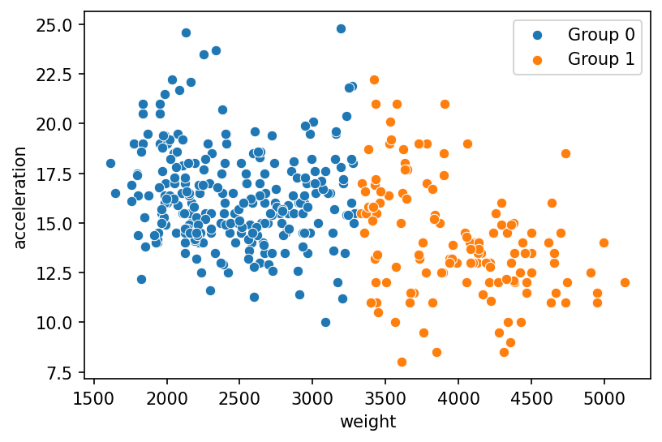

```python
plt.figure(dpi=150)
sns.scatterplot(x="weight", y="acceleration", data=auto.iloc[h_groups.labels_==0])
sns.scatterplot(x="weight", y="acceleration", data=auto.iloc[h_groups.labels_==1])
plt.legend(["Group 0", "Group 1"])
plt.plot()
```

```
[]
```

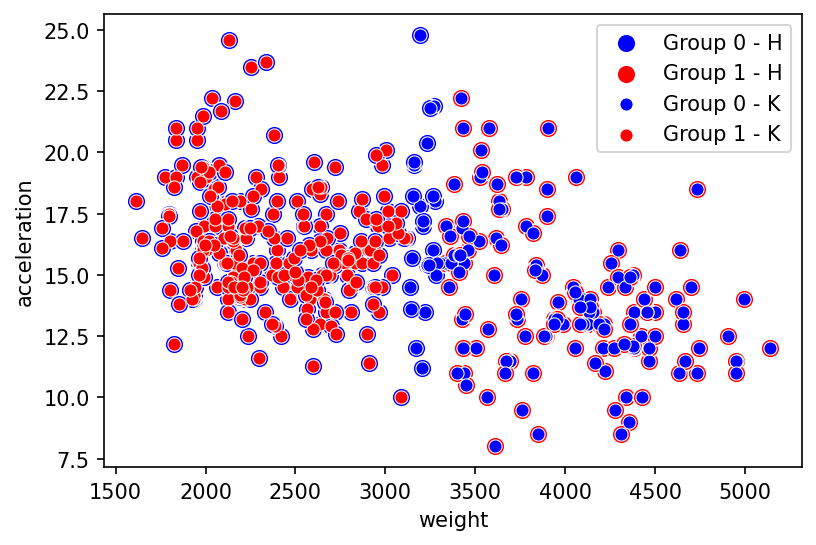

```python
plt.figure(dpi=150)

groups = KMeans(n_clusters=2).fit(X).predict(X)

sns.scatterplot(x="weight", y="acceleration", s=80, color ="blue", data=auto.iloc[h_groups.labels_==0])
sns.scatterplot(x="weight", y="acceleration", s=80, color = "red", data=auto.iloc[h_groups.labels_==1])

sns.scatterplot(x="weight", y="acceleration", s=40, color="blue", data=auto.iloc[groups==0])
sns.scatterplot(x="weight", y="acceleration", s=40, color= "red", data=auto.iloc[groups==1])
plt.legend(["Group 0 - H", "Group 1 - H", "Group 0 - K", "Group 1 - K"])
plt.plot()
```

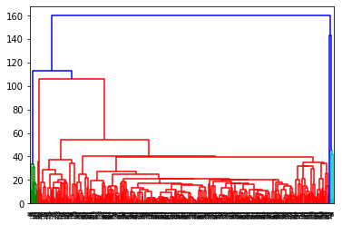

```python
dendrogram(linkage(X));
```